*A mi esposa por su infinita paciencia y apoyo permanente desde el inicio de estudios, haciendo las mil y una tareas que pueden lucir pequeñas, pero sin las cuales simplemente hubiese sido imposible culminar con éxito la maestría.*

*A mi tutor, Profesor Dr. Ricardo Rico, ucevista ejemplar, por su dedicación y entrega para que continuemos sin desmayo el esfuerzo por hacer una investigación de alta calidad en el país.*

*A los amigos del mundo de la cultura, Yausen Villegas y Omar Mora por todos los datos, explicaciones e información proporcionada que sirvieron de base primaria para la realización de esta tesis.*

# Introducción

## Motivación

Existe una creciente percepción acerca de la pérdida del valor intangible que implica la identidad cultural de una nación. Si bien la cultura siempre fluye a través de los pueblos, la crítica se dirige al rol hegemónico impuesto por la llamada globalización. Gracias al desarrollo de nuevas tecnologías en comunicación e información y la difusión masiva e intensiva de los valores culturales de quienes monopolizan tales recursos, se ha promovido una cultura cosmopolita que amenaza con reducir la diversidad cultural del planeta. De allí que los países defiendan los valores culturales que los identifican y distinguen como únicos en relación a los demás, a través de políticas públicas y sus correspondientes presupuestos. Para medir la gestión cultural se requieren modelos causales que generen indicadores de avance y orienten futuras intervenciones. Con este objetivo, la presente investigación aspira construir un *Modelo General Lineal Multinivel o MGLM* para el caso venezolano, utilizando técnicas del *aprendizaje automático o machine learning*.

Venezuela incluye en el Preámbulo de su Constitución (Asamblea Nacional 2009), el conjunto de valores que la identifican como país multiétnico y pluricultural. Tales fines se despliegan en los objetivos de los planes nacionales plurianuales y en las leyes de presupuestos y en otras normas, como la Ley Orgánica de la Cultura (Asamblea Nacional 2014), a través de la asignación de recursos a entes, programas y proyectos de naturaleza cultural. La duda es si tal accionar es eficaz para preservar y fortalecer la identidad cultural del país en un mundo globalizado.

La institucionalidad cultural, cuyo ente rector oficial actual es el Ministerio del Poder Popular para la Cultura, en adelante MPPC, es un sistema complejo con múltiples organismos públicos, privados y comunitarios asociados, así como individualidades y agrupaciones de variada índole, todas ellas dedicadas al quehacer cultural. Este sistema, que se remonta a la independencia al crearse los primeros entes culturales, evoluciona siguiendo ciertas reglas probabilísticas que deben ser develadas con las herramientas disponibles de la ciencia de datos. Así, pueden identificarse patrones entre miles o millones de datos, aparentemente inconexos, almacenados y registrados en multiplicidad de formatos en los entes que forman el sistema y de donde provendrá la información para la investigación.

En Venezuela la cultura suele analizarse desde las humanidades y ciencias sociales, por lo que una investigación como la presente contribuiría a ampliar el foco, proporcionando métricas para comparar el avance con respecto a los objetivos nacionales planteados y ubicarse en el mapa internacional de la cultura. Se contribuiría además, a suplir la actual carencia de un sistema de información estadística de la cultura, evidenciada por Castellanos (Castellanos Ribot 2017) en los informes del Sistema Subregional de Información Estadística del MERCOSUR, SIC SUR, en los cuales Venezuela aparece a lo largo de varios años, con datos desactualizados o inexistentes en diversas dimensiones culturales.

## Definición de Cultura según la UNESCO

A efectos de la investigación se empleará la definición formulada en el año 2001, en la Declaración Universal sobre la Diversidad Cultural (UNESCO 2011b):

> La cultura debe ser considerada como el conjunto de los rasgos distintivos espirituales y materiales, intelectuales y afectivos que caracterizan a una sociedad o a un grupo social y que abarca, además de las artes y las letras, los modos de vida, las maneras de vivir juntos, los sistemas de valores, las tradiciones y las creencias[^1].

UNESCO propone un conjunto de indicadores para medir la cultura en cada país concentrada en tres ejes principales, como:

1. Un sector de actividad económica;
2. Una serie de recursos que agrega valor a las intervenciones de desarrollo y aumenta su impacto; y
3. Un marco sostenible para la cohesión social y la paz, indispensable para el desarrollo humano.

También promueve un conjunto de Indicadores de Cultura para el Desarrollo (UNESCO 2012) conocidos por sus siglas IUCD[^2], los cuales están dirigidos a la sensibilización y formulación de políticas, fundamentados en una metodología especialmente diseñada para que los países midan el papel de la cultura en los procesos de desarrollo nacionales. Los IUCD apuntan a que los países elaboren políticas mejor informadas, basadas en datos reales, y sobre todo integrar la cultura en las estrategias de desarrollo, contribuyendo a la implementación de la Convención de la UNESCO de 2005 sobre la Protección y la Promoción de la Diversidad de las Expresiones Culturales. Además, UNESCO proporciona una metodología y un manual (UNESCO 2011a, 2014) con 22 indicadores y siete (7) dimensiones del desarrollo: Economía, Educación, Gobernanza, Participación Social, Igualdad de Género, Comunicación y Patrimonio. En la Metodología se utilizan algunas de estas dimensiones y otras más para referenciar las variables explicativas del modelo. Sin embargo es prudente advertir siguiendo a Bonet (p. 3) que:

> Más allá de los objetivos y marco metodológico de cada investigación en particular, no existen modelos globales y completos de análisis del sector cultural, ni probablemente nunca existirán. El contexto de cualquier ejercicio de diseño de un plan de estadísticas culturales debe, pues, aceptar la existencia de diversos modelos interpretativos al mismo tiempo, a veces a medio construir, que responden a enfoques disciplinares dispares. Uno debe aprender a trabajar con información asimétrica en un campo de actividad donde se mezcla lo mercantil con lo no mercantil, lo público con lo privado, lo industrial con lo artesanal, el bien con el servicio, lo tangible con lo intangible, etc. Ningún análisis permite por si solo una evaluación exacta de la realidad, y del impacto social y económico sobre un territorio de las distintas políticas culturales públicas y privadas existentes.

Esta óptica será respetada en la investigación.

# Objetivos de la investigación

## Planteamiento

Uno de los objetivos centrales de la política cultural es el *incremento de la participación*, entendida como el grado de involucramiento de la población del país con las actividades culturales promovidas por el sistema cultural institucional. En el sistema cultural venezolano, se identifican dos vertientes, la *institucional o convencional*, que hunde sus raíces en lo que se solía llamar como “Bellas Artes”, y la identificada con la llamada “Cultura Popular”. La primera tiene rasgos de actividad de élites, vinculada fuertemente a la existencia de sedes especializados donde se cultiva a lo largo de procesos educativos formales, y luego se comparte y difunde en espacios creados especialmente para ello. Su desarrollo ha sido paralelo al del crecimiento de los recursos económicos del país desde los inicios del siglo XX con la conversión de país agrícola a petrolero. La participación en la cultura convencional, dependerá del crecimiento y estado de la infraestructura y del talento humano disponible. Estos factores tendrán mayores posibilidades de desarrollarse, si se conjugan los recursos y la voluntad política y social para impulsarlos. Este último elemento es importante porque aunque la mayor disponibilidad de recursos aparenta ser una condición para el crecimiento de la actividad cultural, el resultado obtenido puede ser escaso e incluso nulo, si el interés predominante está en el desarrollo de otras iniciativas con poco o ningún valor cultural. Un interés real se reflejará en la proporción de los presupuestos globales nacionales, estadales y municipales dedicados a la cultura, así como en el aporte económico del sector privado y comunitario. También se evidenciará en la cantidad y tipos de eventos programados y ejecutados desde la institucionalidad cultural, cada una con su propia capacidad para atraer interesados.

La participación cultural convencional crecerá en la medida que exista disponibilidad de recursos para impulsar la formación del talento y el desarrollo de una infraestructura de apoyo, junto a una oferta variada y atractiva de eventos. La mayor riqueza de una región se relaciona a su vez, con una pujante actividad económica, presencia significativa de población urbana y posiblemente alto nivel de vida, reflejado en niveles educativos superiores y menores niveles de pobreza. Estos hechos se retroalimentan, convirtiéndose en *atractores* generadores de desigualdad entre las regiones, favoreciendo la concentración de infraestructura y actividades culturales de manera creciente en unas pocas en detrimento de la mayoría. Esta dinámica coloca a los habitantes de estas regiones en riesgo de ser más fácilmente tentados por la cultura superficial y fragmentaria de la globalización, llevándolos a desconocer o menospreciar los valores culturales nativos. Es de esperar que estos factores, y su dinámica compleja, influyan en la participación cultural convencional.

La cultura popular es más bien fruto del saber y quehacer diario comunitario, acumulado a lo largo de años e incluso siglos, convirtiéndose en tradición, de modo que sale adelante con más o menos independencia de los recursos que el sector público o privado puedan invertir. La participación ocurre aquí como un fenómeno vegetativo, en el cual la práctica se inicia en el seno de la propia familia o comunidad, de abuelos a nietos, sin requerir necesariamente la existencia de una institucionalidad formal para su formación o difusión. La organización aparece, pero no de manera externa a los propios practicantes o asistentes de la actividad. Ésta última puede realizarse en cualquier espacio si así lo decide el cultor o la comunidad. El rol como participante se incrementa en la medida que el individuo siente que se refuerza su sentido de pertenencia a la comunidad, el orgullo por lo que es propio y distintivo, y además se eleva el prestigio y la valoración de los ejecutantes.

La participación en la cultura popular dependerá de la presencia de un fuerte sentido de identidad o pertenencia cultural a una determinada comunidad. Esta se desarrolla a través de la difusión o transmisión de los memes culturales de una generación a la siguiente. Además, exige la concurrencia de dos situaciones: primero, la convivencia de generaciones distintas en un mismo espacio y segundo, que la nueva generación perciba la práctica como importante o prestigiosa para quien la ejecuta, y por tanto digna de ser cultivada y preservada. Es más factible encontrar esta conjunción en espacios rurales e indígenas que en las grandes ciudades. En estas últimas con comunidades y familias nucleares cada vez más pequeñas y desintegradas, los adultos mayores son considerados más como una carga que como los repositorios de una cultura. La situación tiende a destruir las tradiciones y a desplazar los valores culturales propios, por los difundidos por las grandes transnacionales de la comunicación y del mundo digital.

Será más probable entonces, que la participación en la cultura popular ocurra en poblaciones rurales o indígenas, con largos períodos de asentamiento en los cuales haya sido posible madurar una historia y una cultura con sello propio y donde los cultores, en especial aquellos de mayor edad, sean apreciados. También podría ocurrir en regiones urbanas con comunidades que siguen manteniendo un fuerte vínculo con lo rural. A su vez, la asistencia a eventos culturales de tipo popular, oscilará a lo largo del año de acuerdo a las actividades conmemorativas de eventos mágico-religiosos, históricos, ecológicos, climáticos, vinculados al cultivo u otras faenas laborales. El turismo cultural es un indicador de la presencia de los factores expuestos, dado que las personas se dirigen con preferencia hacia estos lugares durante esas fechas en cantidades que superan los cientos de miles o millones de personas.

Si bien la presencia de recursos públicos y privados puede impulsar la participación en la cultura popular, su ausencia no implica el fin de estas actividades. Y, por otro lado, su uso incontrolado bajo una errónea interpretación de la participación puede, y ha llevado, a tergiversar o sacrificar la esencia de una práctica cultural en aras de una supuesta mayor aceptación por el público. La disponibilidad de recursos solo tendrá éxito en este caso, si existe una comunidad que se identifica o es susceptible de identificarse con los valores que se intenta impulsar. Es de esperar que la participación en la cultura popular no sea influida decisivamente por un incremento en la actividad económica, la infraestructura disponible, o los niveles de vida de la población, porque ella ocurre sin problema, en lugares alejados de las grandes concentraciones urbanas donde no es raro que la población tenga un nivel de vida más bajo, mayor carencia de servicios y niveles educativos inferiores.

La teoría expuesta puede *representarse* vía un modelo estocástico con ayuda del machine learning que capture los elementos complejos del sistema, como los *efectos no lineales y las interrelaciones* entre los distintos *niveles jerárquicos* del sistema. Para mantener al modelo simple pero que aporte información valiosa, se elige como variable dependiente a la *asistencia del público en los eventos promovidos por la institucionalidad cultural durante el año 2018*. Esta variable es afectada por diversos elementos: disponibilidad de recursos, talento humano, infraestructura cultural, actividad económica, oferta y tipo de eventos, temporada del año, tipo de población y nivel de vida. Todos ellos pueden incorporarse directamente o a través de variables indicadoras o *proxies* de los mismos y son susceptibles de ser influenciadas por la acción pública. Lo esencial para la gestión de las políticas culturales es que el modelo refleje adecuadamente la teoría cultural que se intenta representar con un conjunto de variables interpretable por los responsables de su manejo.

Por las razones expuestas se construirá un *Modelo General Lineal Múltinivel o Jerárquico*[^3], en adelante MGLM. Este tipo de modelo permite incluir relaciones no lineales entre las variables predictoras y la dependiente, así como términos de interacción entre varios niveles, si los mismos son sospechados de antemano. En este caso, la asistencia es medida a nivel de municipios y luego es agrupada por estados. El anidamiento implica que los municipios de un estado reciben influencias comunes, por lo cual las observaciones de municipios de un mismo estado, no son independientes entre sí, lo que se traduciría, en una subestimación de los errores estándar de los coeficientes de regresión. A su vez, se obtendrían intervalos de confianza estrechos y p-valores pequeños, lo que conduce a interpretaciones erróneas acerca del efecto de una variable predictora sobre la dependiente, cuando en realidad el efecto podría ser producto del azar, es decir un incremento en la probabilidad de cometer un error de Tipo I.

Un Modelo Lineal Generalizado sería insuficiente para reflejar la influencia estadal del desarrollo socio-económico en la cultura, en cambio los MGLM [Hox *et al.* (2018); Lee *et al.* (2017);Lee (2017)), utilizan coeficientes aleatorios como variables de otros niveles, mostrando adecuadamente la estructura jerárquica de los datos. Con los MGLM se obtienen estimaciones adecuados de los errores estándar, se facilita el análisis de la variación entre grupos y se construyen pruebas válidas e intervalos de confianza. Aunque el análisis a un nivel puede realizarse agregando o desagregando los datos se pueden cometer las *falacias ecológica o atomística*. En la primera se infieren la naturaleza de los municipios, a partir de las estadísticas agregadas del estado, y en la segunda, el error se comete al considerar que las asociaciones encontradas en el nivel de los municipios, pueden extrapolarse a los estados. Como la asimetría territorial entre las regiones venezolanas es un hecho generalizado [Ancidey (2018)), sería un grave error descuidar estas diferencias.

##Objetivo de la investigación

## Objetivo general

Representar mediante un modelo multinivel la dinámica subyacente a la institucionalidad cultural de Venezuela.

## Objetivos específicos

1. Determinar las unidades de análisis documentales de investigación que permiten la construcción de la Base de Datos, a través de la recopilación, integración, depuración, normalización e imputación de los registros existentes.
2. Investigar las variables inherentes de la institucionalidad cultural venezolana mediante un análisis estadístico exploratorio de datos con ayuda de gráficos, correlaciones, asociaciones, gráficos de dispersión y análisis de componentes principales o de correspondencia.
3. Construir el modelo multinivel a partir de las variables identificadas como de mayor influencia en la dinámica cultural institucional.
4. Proponer indicadores de gestión en base al modelo sobre la eficacia de las políticas culturales en cuanto a la participación.

## Justificación

El desarrollo de nuevas metodologías para el manejo de los datos es un aporte a la eficiencia y mejora de los procesos de los entes públicos responsables de la cultura en Venezuela. Con un mejor manejo de los datos será posible realizar de manera más fácil y rápida, el control y seguimiento de las actividades realizadas y contribuir a una cultura del dato, necesaria en toda la administración pública.

La utilidad del modelo estará en su capacidad predictiva a partir de un conjunto manejable de las variables más pertinentes. La disponibilidad de un modelo con capacidad predictiva o pronóstica, contribuirá a la evaluación del desempeño institucional de los entes culturales del país y en particular para el desarrollo de políticas públicas culturales con fundamentos científicos.

## Limitaciones

La ausencia de una cultura del dato en las instituciones venezolanos tiene como consecuencia que la disponibilidad de estos últimos sea una de las principales limitaciones. La inexistencia de registros o bases de datos sistemáticas acerca de la cultura es uno de los mayores obstáculos. Aquellos disponibles se reducen a tablas en hojas de cálculo que llevan las instituciones para sus fines particulares. Estos no guardan coherencia entre sí y se requiere de esfuerzo e investigación con los responsables para comprender el significado de las variables utilizadas. Empero, es una regla metodológica esencial en la investigación preliminar, no descartar ningún dato sin tener evidencia firme de su inutilidad, por ser un error no corregible o ser redundante. Esto obliga a una afinación mayor en los procesos de imputación de datos y ser más creativos en el uso de los métodos usuales de la literatura.

La investigación se enfocará en los entes oficiales por su responsabilidad en la conducción de las políticas públicas culturales. La institucionalidad en manos privadas y comunitarias se integra dentro del marco global de las políticas públicas culturales. El propósito es desarrollar el modelo al mayor nivel de desagregación geográfica posible para tomar en cuenta las diferencias y similitudes, las cuales son suavizadas a mayores niveles de agregación. De allí la elección de realizar los análisis hasta el nivel de municipios del país, dada la ausencia de datos claves para las parroquias.

# Metodología

## Modelos Generales Lineales Multinivel

Los coeficientes de intercepto y pendiente son los coeficientes aleatorios. Su variación no debe ser totalmente aleatoria, por lo que se puede explicar parte de la variación vía la introducción de variables de un nivel superior. Generalmente se explica solo parte de las variaciones, por lo que se espera que permanezca alguna variación residual inexplicable.

Los coeficientes de regresión $\gamma$ no varían entre los estados, por lo cual carecen del subscrito j, y por aplicarse a los estados, se denominan *coeficientes fijos* del modelo. Toda la variación entre estados que queda en los coeficientes de $\beta$, después de predecirlos con la variable de estado Zj, se supone que es una variación del error residual. Esta es capturada por los términos de error residual u_j los cuales sí llevan el subscrito j para indicar el estado al que pertenecen.

El segmento [$\gamma$_00+$\gamma$_10 X_1ij+$\gamma$_20 X_2ij+$\gamma$_01 Z_j+$\gamma$_11 X_1ij Z_j+$\gamma$_21 X_2ij Z_j ] contiene los coeficientes fijos siendo la parte *fija o determinista* del modelo. La restante con los errores aleatorios es la parte *aleatoria o estocástica* del modelo. Los términos X_1ij Z_j y X_2ij Z_j son de interacción y aparecen como consecuencia de modelar $\beta$_1j de una variable del municipio X_ij con la variable de estado Z. Así, el efecto moderador de Z sobre la relación entre la variable dependiente Y y el predictor X, se expresa en la versión de ecuación simple del modelo como una interacción entre niveles. La interpretación de los términos de interacción en el análisis de regresión múltiple es compleja, pero lo relevante a tener en cuenta es que la interpretación sustantiva de los coeficientes en modelos con interacciones es mucho más simple si las variables que configuran la interacción se expresan como desviaciones de sus respectivas medias.

En el análisis de regresión múltiple los coeficientes de regresión se estandarizan a menudo porque se facilita la interpretación cuando se desea comparar los efectos de diferentes variables dentro de una muestra. Pero si el objetivo es comparar las estimaciones de los parámetros de diferentes muestras entre sí, se deben utilizar coeficientes no estandarizados. Para estandarizar lo mejor es derivar los coeficientes de la regresión estandarizada a partir de los coeficientes no estandarizados. Si existe una parte aleatoria complicada, que incluye componentes aleatorios para pendientes de regresión, se debería pensar cuidadosamente acerca de la escala de las variables explicativas.

## Selección de variables

La selección de variables busca un modelo que se ajuste bien a los datos y que a la vez sea posible buscar un equilibrio entre bondad de ajuste y sencillez. Puede verse como un problema de regularización que asegure la *ortogonalidad* de las variables, para ello se siguen los pasos siguientes:

1. Visualización y cálculo de correlación y asociación entre las posibles variables predictoras, a los fines de identificar *colinealidad* o asociación entre alguna de ellas, y eliminar las redundantes.
2. Uso de *métodos de aprendizaje* no supervisado que permitan identificar las predictoras con mayor fuerza explicativa o una combinación lineal de las mismas, por ejemplo vía un *Análisis de Componentes Principales* o ACP o un Análisis de Correspondencia para variables categóricas.
3. Uso de métodos *por paso (stepwise)* como *Eliminación hacia Atrás (Backward elimination)*, *Eliminación hacia Adelante (Forward selection)*, *Selección Paso a Paso (Stepwise selection)* y *Selección del mejor subconjunto*.

## Paquetes de R para Modelos Multinivel

Existen diversas opciones para el manejo de modelos multinivel pero R los aventaja por su carácter de software libre y gratuito, la permanente actualización de su comunidad de usuarios y en ser de hecho el estándar en el mundo académico. Field *et al* (2012) señala varios paquetes que se pueden utilizar: nlme (Pinheiro *et al.* 2019) y lme4 (Bates *et al.* 2019). El paquete nlme permite modelar la estructura de covarianza. Lee, Rönnegård, & Noh (Lee 2017) presentan los paquetes HGML (hierarchical generalized linear models) y Doble HGML o DHGML (Lee & Noh 2018). El paquete dhglm incluye varias clases de modelos incluyendo: modelos lineales generalizados (MLGe), MLGe conjuntos, MLGe con efectos aleatorios (conocidos como HGLMs) y HGLMs incluyendo modelos para los parámetros de dispersión, incluyendo HGLMs dobles (DHGLMs) introducidos posteriormente.

Para el desarrollo de la investigación se ensayará con los paquetes disponibles, pero al final se elegirá uno solo para la presentación de los resultados, de acuerdo a la facilidad de uso para los eventuales operadores de la institucionalidad cultural.

## Operacionalización del indicador

A continuación se detalla la operacionalización del indicador o variable dependiente del modelo:

**Variable dependiente**

*Asistencia*: Mide los niveles de participación de la población en eventos municipales culturales, como exposiciones, ferias, talleres, exposiciones en museos, visitas a bibliotecas, sitios históricos-culturales, entre otros, como asistentes en calidad de público o consumidores los bienes y servicios culturales ofrecidos en el año 2018. La información es recopilada a través de los entes institucionales regionales de la cultura. La unidad de análisis es el municipio como primer nivel y el estado como segundo nivel.

**Variables independientes**

Por su parte las variables independientes se extraen de los diversos registros de datos disponibles en los entes oficiales a cargo de la cultura y entes relacionados con el presupuesto y finanzas públicas, estadísticas nacionales, turismo y división político administrativa del país. Algunas de estas variables ya han sido analizadas en investigaciones preliminares. Siguiendo las orientaciones de la UNESCO y su adaptación al caso venezolano, se agrupan por las siguientes dimensiones:

*Sociales*

- Educación: Población escolarizada/ Niveles de alfabetización por estado
- Pobreza: Indicador de niveles de pobreza por municipios.

*Económico-Financiero*

- Actividad Económica por Entidad Federal: establecimientos económicos por estados según último censo industrial de 2012.
- Presupuesto de Municipios: Total y Sector 09 Cultura y Comunicación, por cada año y total acumulado en el período 2008-2018.

*Presupuesto de Entidades Federales proyectado a los municipios de acuerdo a su población: Total y Sector 09 Cultura y Comunicación, por cada año y total acumulado en el período 2008-2018.

*PIB total y pér cápita correlacionado con la creación de Sedes de Sedes Culturales.

*Infraestructural cultural*

- Sedes culturales en 2018 discriminadas por Estado, Municipio, Parroquia, Poblado o Ciudad, ente, tipo de sede, cantidad de trabajadores, beneficiarios, naturaleza de la propiedad, año de fundación, Área Cultural y Plataforma Cultural de adscripción.
- Espacios de la Misión Cultura en 2018 por Estado, Municipio, Parroquia, Poblado o Ciudad, Tipo de Sede, cantidad de animadores, tutores y beneficiarios, año de fundación, Área Cultural y Plataforma Cultural de adscripción.

*Turismo*

- Afluencia turística por Entidad Federal en el período 2015-2018.

*Actividad Cultural*

- Actividades de Gabinetes Culturales por fecha, ubicación, beneficiarios, área y Plataforma Cultural.
- Cultores: Todo aquel dedicado a determinada actividad cultural de manera permanente y que se considere a sí mismo como: Cultor o Cultora, Artista, Intelectual, Artesano o Artesana. Incluye a las personas dedicadas a la promoción y difusión cultural.

*Geografía*

- Extensión territorial de Estados y Municipios

*Población de Estados, Municipios y Parroquias proyectada quinquenalmente de 2000 a 2050.

*Organización*

- Plataformas Culturales, Entes adscritos y Gabinetes Culturales Territoriales
- Personal por entes y jerarquía.

*Política Cultural*

- Descripción de las Actividades de Gabinetes en 2018.
- Parroquias priorizadas.
- La cultura en Plan de la Patria 2013-2019.

# Resultados

## Presupuesto dedicado a cultura

### Nacional

Los presupuestos nacionales aparecen contemplados en las leyes anuales de presupuesto. En la sección correspondiente a la *Exposición de Motivos* se presentan, además de los supuestos bases para la formulación presupuestaria del año, un apéndice con las estadísticas de los recursos (ingresos) y egresos de los cinco años anteriores. En el caso de los egresos, son desglosados por los siguientes conceptos y sus combinaciones:

- institución
- fuentes de financiamiento
- partidas
- conceptos principales de los egresos
- clasificación económica
- clasificación sectorial
- ámbito regional: entidades federales y municipios.

El manejo de los datos presupuestarios se realiza en base a los siguientes criterios:

1. La información contenida en las Exposiciones de Motivos se utiliza con prioridad en la investigación al resto del contenido de las leyes anuales de presupuestos. La razón estriba en que los resultados que se presentan de los cinco (5) años anteriores, contienen los presupuestos realmente ejecutados, con las modificaciones realizadas en el transcurso de cada año debido a la aprobación de créditos adicionales.
2. Como las modificaciones a las cifras presupuestarias continúan, incluso en los años siguientes al cierre del ejercicio, se prefiere utilizar las exposiciones de motivos que contengan el año de interés como el primero de la serie de cinco años. Al operar de esta forma se cuenta con cifras más estables, de modo que si el interés es presentar, por ejemplo los datos del año 1998, se opta por elegir la exposición de motivos del año 2003, porque contiene la información de los presupuestos de los cinco años anteriores, de 1998 a 2002. Es más probable que para la elaboración del proyecto de ley de presupuesto del año 2003, los datos de 1998 permanezcan sin modificaciones. Este criterio se aplica para los años de 1998 hasta 2011, luego simplemente se utiliza la última exposición de motivos publicada, es decir la del año 2016.
3. En ausencia de las exposiciones de motivos, como ha venido ocurriendo en los últimos tres años, 2017, 2018 y 2019, los datos se estiman directamente del contenido de cada ley y mediante supuestos razonables. Si bien esto limita la obtención de algunas de las clasificaciones del gasto, en especial la sectorial, al menos para el Sector 09 relativo a Cultura y Comunicación Social, fue posible obtener los datos directamente de la ONAPRE para las Entidades Federales y Municipios en el período de 2008 a 2018 y compensar la ausencia de las exposiciones de motivos de 2017 y 2018 .
4. Las unidades monetarias se estandarizan todas a miles de bolívares fuertes, moneda vigente de 2007 hasta 2018. Para ello se divide entre mil (1.000) los valores de la moneda utilizada desde el año 1879 hasta el 2007. Es innecesaria la conversión a Bolívar Soberano, vigente desde el 20 de agosto de 2018, porque los datos presupuestarios hasta ese año están expresados en bolívares fuertes. En todo caso para convertir de Bolívares fuertes a soberanos, basta con dividir a los primeros entre cien mil (100.000).

Tomando los criterios anteriores, se determina el aporte del presupuesto público a la cultura, siguiendo los pasos siguientes:

1. Identificar para cada año, las contribuciones del nivel nacional, estadal y municipal, las cuales aparecen contempladas como *Sector 09, Cultura y Comunicación Social*, en los cuadros correspondientes a la clasificación sectorial del gasto para cada uno de estos niveles.
2. Reexpresar en términos reales el valor de los presupuestos nominales que aparecen en las Exposiciones de Motivos.
3. Sumar las contribuciones de cada nivel para obtener el aporte total.

La evolución de la magnitud del aporte puede observarse comparando el presupuesto global y de cada nivel, contra el presupuesto del Sector 09.

### Magnitud relativa del presupuesto dedicado a la cultura

El presupuesto público destinado a la cultura proviene de los aportes del nivel nacional, estadal y municipal. El primer nivel corresponde a los aportes que los órganos del Poder Público Nacional y sus entes adscritos destinan al Sector 09, Cultura y Comunicación y Social. El segundo nivel lo constituyen los aportes de las Gobernaciones y el tercero los de las Alcaldías Municipales. Ahora bien, del primer nivel se transfieren recursos a los Estados y Municipios los cuales, junto a los ingresos propios de estos niveles, conforman el presupuesto de egresos de Estados y Municipios. Parte de estos recursos son destinados también al Sector 09, es decir gastos de Cultura y Comunicación Social de Gobernaciones y Alcaldías.

La relativa estabilidad en la conformación de los presupuestos (promedios y medianas de los estados: 2,94% y 2,94%; y para los municipios: 56,17% y 56,47%) permiten seleccionar un año típico, como 2011, para mostrar con un *diagrama aluvial o de Sankey*, ver figuras @ref(fig:Aluvial1) y @ref(fig:Aluvial2), la magnitud relativa del presupuesto asignado a la cultura, del Poder Público Nacional, Regional y Municipal, incluyendo las transferencias a estas dos últimos niveles.

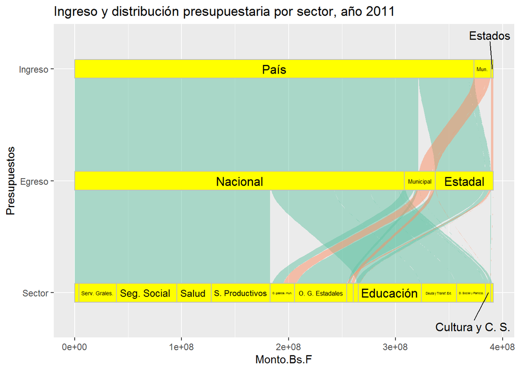

Diagrama aluvial del presupuesto nacional en 2011

O también

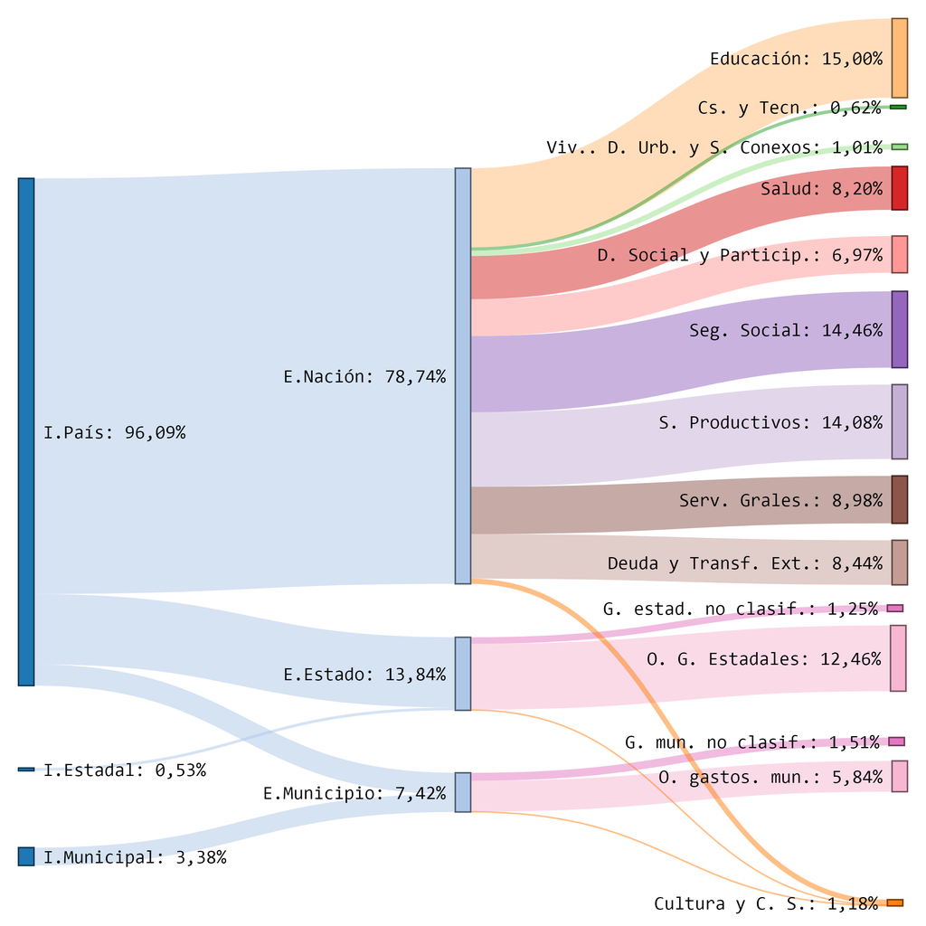

Distribución de ingresos, egresos y gastos por sector en 2011

El valor porcentual del presupuesto destinado al Sector Cultura y Comunicación Social en 2011, es de 1,18%. Como se evidencia de la figura @ref(fig:evolSector), *la proporción del presupuesto público destinada a la cultura*, (al igual que los otros sectores sociales), se mantiene estable alrededor de este valor a lo largo de los años pese a las variaciones del presupuesto público:

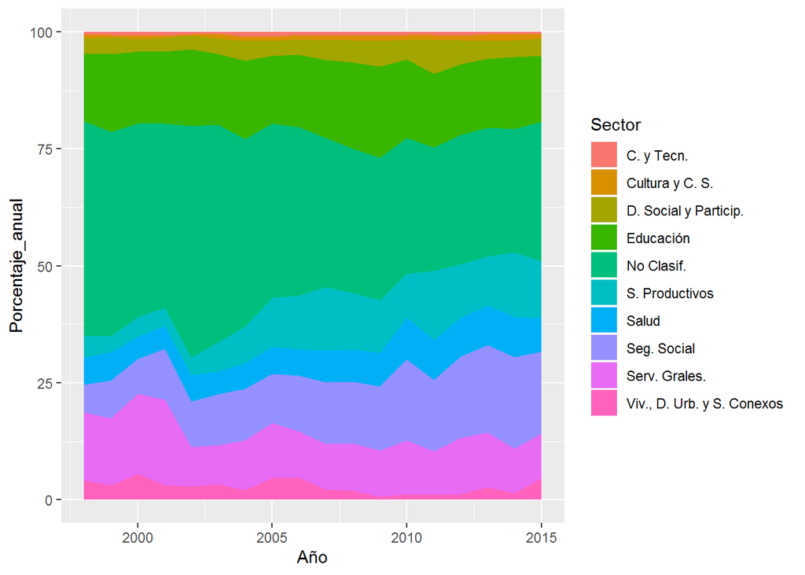

```r
library(ggplot2)
library(dplyr)
Sec_Nac <- read.csv("Sec_Nac.csv", sep=";",dec = ",")
Sec_Nac<-as.data.frame(Sec_Nac)
se<-ggplot(Sec_Nac, aes(x = Año, y = Porcentaje_anual, fill=Sector)) +
  geom_area()
se
```

### Reexpresión de los valores nominales del presupuesto público

Convencionalmente la reexpresión a términos reales del presupuesto público en situaciones de inflación se realiza (ver [Red-DESC](https://www.escr-net.org/es/docs/i/506523)) usando la siguiente fórmula:

$$\begin{equation}
Valor\; real= \frac{Valor\; nominal\times \;índice\; de\; inflación\; actual}{índice\; de\; inflación\; del\; año\; previo\; o\; año\; base}
\end{equation}$$

Cuando la inflación es moderada la fórmula es útil, sin embargo en situaciones de hiperinflación el índice anual, que es el acumulado a diciembre de cada año, no refleja apropiadamente la corrección, en vista de la gran variabilidad de precios de mes a mes, e incluso de un día al otro y hasta de una hora a la siguiente. La fórmula anterior seguiría siendo útil dado el caso que todo el presupuesto público se ejecutase a fines del mes de diciembre de cada año. La realidad señala en cambio, que la mayor parte del presupuesto se ejecuta mensualmente, a través de la ejecución de los llamados *dozavos*, para el pago fundamentalmente de gasto corriente, integrado por gastos de personal, suministros y servicios, es decir las partidas 4.01, 4.02 y 4.03 del clasificador presupuestario venezolano.

Ahora bien como el gasto es mensual, se puede dividir el presupuesto nominal ejecutado de cada año en doce (12) porciones correspondientes al monto ejecutado mensualmente. Luego, cada una estas porciones se reexpresan en términos reales usando la misma fórmula anterior, pero utilizando el Índice de Precios mensual en vez del anual:

$$\begin{equation}
Valor\; real\;mes_i= \frac{Valor\; nominal\;mes_i\times \;índice\; de\; inflación\; del\;mes_i}{índice\; de\; inflación\; del\; mes\, base}
\end{equation}$$

O también

$$\begin{equation}
Valor\; real\;mes_i= Valor\; nominal\;mes_i\times \;f_i\quad donde \quad i=mes=1,2,\dots,12
\end{equation}$$

con
$$\begin{equation}
f_i=\frac{índice\; de\; inflación\; del\;mes_i}{índice\; de\; inflación\; del\; mes\, base}
\end{equation}$$

Para obtener el presupuesto del año se aplicaría la siguiente fórmula:

$$\begin{equation}
Presupuesto\;real\;del\;año_j=\sum_{i=1}^{12} \frac{Presupuesto\; nominal\;del\;año_j}{12}\times \;f_i \quad con\quad j: años
\end{equation}$$

El Banco Central de Venezuela publica los actuales índices de precios al consumidor tomando el año 2008 como año base, más precisamente se fija como base 100 el índice de precios para diciembre de 2007. En esta investigación se tomará igualmente este año como base así como con todos los demás indices que se utilizan.

### Estados y Distritos

Los datos proporcionados por la ONAPRE contienen la distribución del Presupuesto de Gastos del Sector 09 “Cultura y Comunicación” en bolívares fuertes de las Entidades Federales, es decir Estados y Distritos Metropolitanos.

#### Grafico de los datos

Se realiza un gráfico boxplot con el presupuesto en valores nominales del año respectivo expresados en bolívares fuertes:

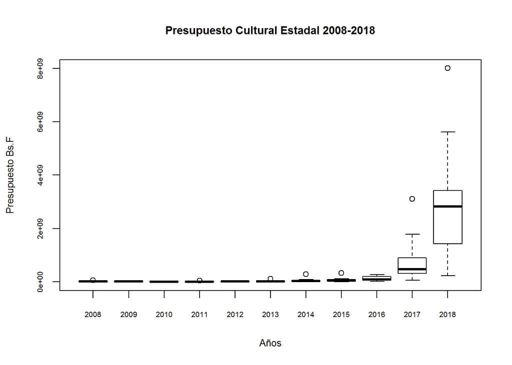

Presupuesto Cultural Estadal en términos nominales, período 2008-2018

Se observa un aparente crecimiento luego de 2016, sin embargo esto puede originarse en la devaluación de la moneda. Por tal motivo se estandarizan (escalan) los datos con respecto al promedio de cada año y se compara con el valor medio, el cual se identifica con una línea recta horizontal a trazos de color rojo:

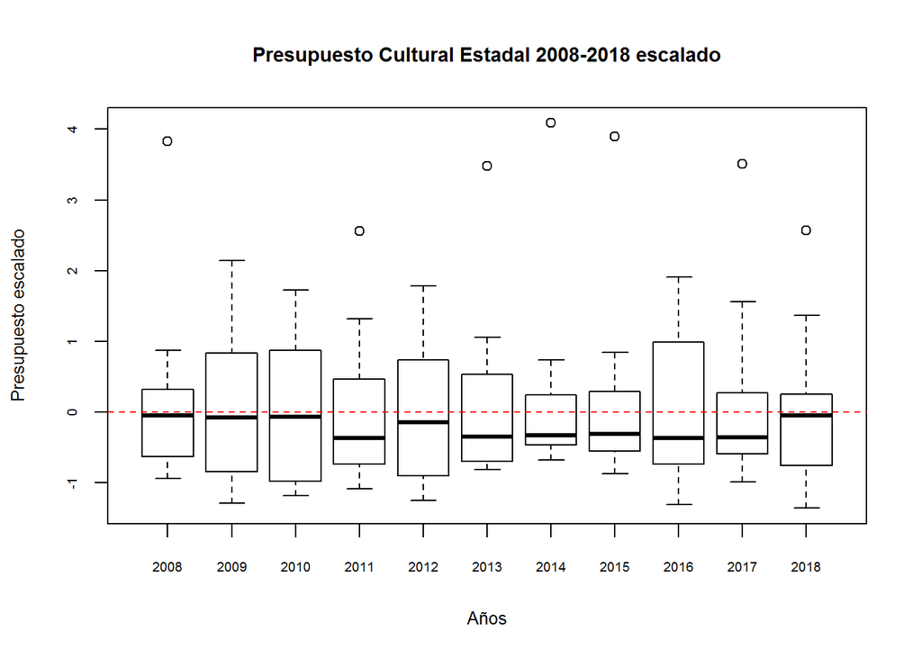

Presupuesto Cultural Estadal 2008-2018 escalado

```r
Cultura_estados_esc<-scale(Cultura_estados)
boxplot(Cultura_estados_esc,xlab="Años",
ylab="Presupuesto escalado",
main="Presupuesto Cultural Estadal 2008-2018 escalado",
cex.lab=0.8,cex.axis=0.6,cex.main=0.9)
abline(h=0,col="red",lty=2)
```

- El resultado notable para Distrito Capital y Miranda de 2013 a 2017 y en 2018 el primero, y 2008, 2009 y 2011 el segundo, es esperable en vista de la concentración cultural en la zona metropolitana de Caracas.
- Es oportuno señalar que los datos originales de la ONAPRE para los estados carecen de los datos del Distrito Capital porque este presupuesto es nacional. Los datos se recogen en el *Título IV* de las leyes anuales de presupuesto, por tanto fue necesario completar la información del Gobierno del Distrito Capital sumando los recursos destinados a la cultura a través de la Secretaría de Identidad Caraqueña y dos entes descentralizados con objetivos culturales: la Fundación Identidad Caraqueña y la Banda Marcial de Caracas.

#### Distribución de los datos

Para analizar la distribución de los datos se toman como muestras tres casos característicos: aquellos sin valores atípicos y los tres casos con los mayores valores atípicos.

La primera muestra corresponde a los años 2009, 2010 y 2012 en los cual no hubo valores atípicos. Se trazan los histogramas respectivos para ver la distribución:

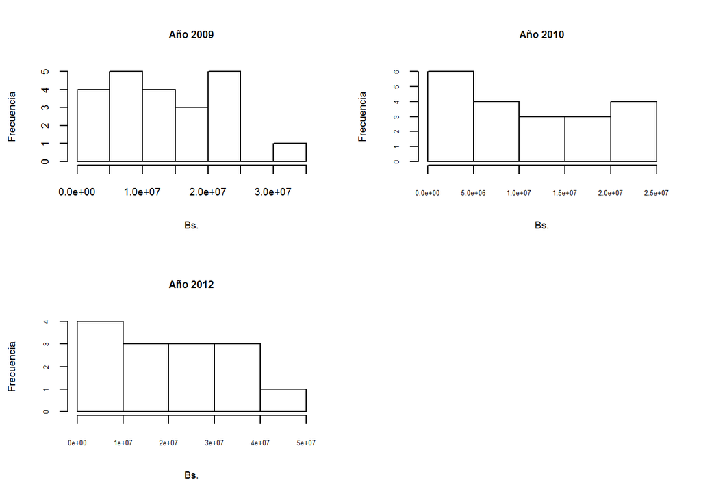

Presupuesto cultural de los estados para años sin valores atípicos

```r
par(mfrow=c(2,2))
y2009<-hist(Cultura_estados$`2009`,xlab="Bs.",
ylab="Frecuencia",
main="Año 2009", cex.lab=0.7,
cex.axis=0.7,cex.main=0.7)
y2010<-hist(Cultura_estados$`2010`,xlab="Bs.",
ylab="Frecuencia",
main="Año 2010", cex.lab=0.7,
cex.axis=0.5,cex.main=0.7)
y2012<-hist(Cultura_estados$`2012`,xlab="Bs.",
ylab="Frecuencia",
main="Año 2012", cex.lab=0.7,
cex.axis=0.5,cex.main=0.7)
```

Se observa una distribución relativamente uniforme entre los estados para estos años.

Luego, se hace lo mismo pero para los años con los mayores valores atípicos 2008, 2014 y 2015:

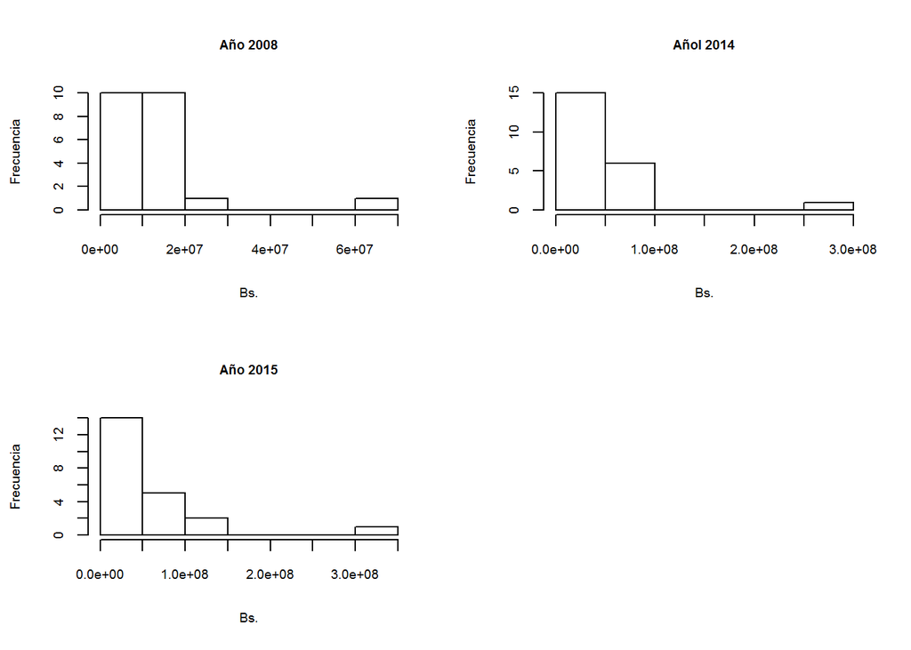

Presupuesto cultural de los estados para años con los mayores valores atípicos

```r
par(mfrow=c(2,2))
y2008<-hist(Cultura_estados$`2008`,xlab="Bs.",
ylab="Frecuencia",
main="Año 2008",
cex.lab=0.7,
cex.axis=0.7,cex.main=0.7)
y2014<-hist(Cultura_estados$`2014`,xlab="Bs.",
ylab="Frecuencia",
main="Añol 2014",
cex.lab=0.7,
cex.axis=0.7,cex.main=0.7)
y2015<-hist(Cultura_estados$`2015`,xlab="Bs.",
ylab="Frecuencia",
main="Año 2015",
cex.lab=0.7,
cex.axis=0.7,cex.main=0.7)
```

El efecto de cola larga es notable en los años con los mayores valores atípicos. Sin embargo la desigualdad no supera un primer orden de magnitud. Lo limitado de la desigualdad entre el presupuesto para la cultura estadal se debe a que como se mostró en las figuras @ref(fig:Aluvial1) y @ref(fig:Aluvial2), los recursos estadales dependen principalmente de las fuentes nacionales, vía situado constitucional o financiamientos especiales. Solo un pequeño porcentaje de los recursos estadales es derivado de los ingresos propios de los estados.

Las distribuciones de origen nacional se reparten proporcionalmente entre las 24 entidades más una proporción en función de la población. Adicionalmente, la proporción sectorial destinada a la cultura se mantiene siempre cercano al 1% del presupuesto total asignado a los estados. De allí que la desigualdad en la asignación cultural estadal, aunque existe, se limita una dispersión de solo un orden de magnitud entre los datos menores y mayores.

#### Reexpresión del presupuesto a valores reales

Otra forma de ver los datos y el cambio en el poder de compra en el período, es reexpresar los datos a valores reales, es decir constantes. Dada la limitación en la información sobre los índices inflacionarios del Banco Central de Venezuela, es posible lograr un resultado similar reexpresando los valores nominales de los bolívares fuertes de cada año en dólares. Para ello y dada la fuerte devaluación de la moneda y el inicio de un proceso hiperinflacionario en 2018, se asumirá una posición conservadora ante la variedad de tasas de cambio existentes en el período analizado. Lo importante, más que los términos absolutos, es la variación. Los criterios son los siguientes:

1. Se utiliza una única tasa para estandarizar los datos.
2. Se usa la tasa no regulada por dar una idea más realista del nivel de inflación en el período en consideración.
3. Se elige la tasa para el momento de la elaboración de los presupuestos, es decir el mes de diciembre del año anterior a la entrada en vigencia de la ley de presupuesto. Así si se trata del presupuesto de 2008, se elige la tasa para diciembre de 2007 y se continúa de la misma manera para los años siguientes hasta el 2018.

En base a los criterios anteriores se construye la matriz con los datos de las tasas de cambio (ver [Cotización histórica del bolívar con respecto al dólar](https://es.wikipedia.org/wiki/Anexo:Cotizaci%C3%B3n_hist%C3%B3rica_del_bol%C3%ADvar_con_respecto_al_d%C3%B3lar)), y se multiplica el presupuesto de cada año y estado por la tasa de cambio correspondiente:

```r
tasa<-rep(c(1/5.7,  1/5.7,  1/5.97,
1/9.14, 1/9.45, 1/17.32,
1/64.10,    1/173.0,    1/910.6,
1/3200, 1/179400),24)
Tasa<-matrix(tasa,ncol=11,byrow = TRUE)
colnames(Tasa)<-c("Tasa2008","Tasa2009","Tasa2010",
"Tasa2011","Tasa2012","Tasa2013","Tasa2014","Tasa2015",
"Tasa2016","Tasa2017","Tasa2018") #Nombres a las columnas de Tasa.
reex<-Cultura_estados*Tasa #Presupesto reexpresado en dólares USD.
```

Con los datos obtenidos anteriormente se construye el gráfico boxplot:

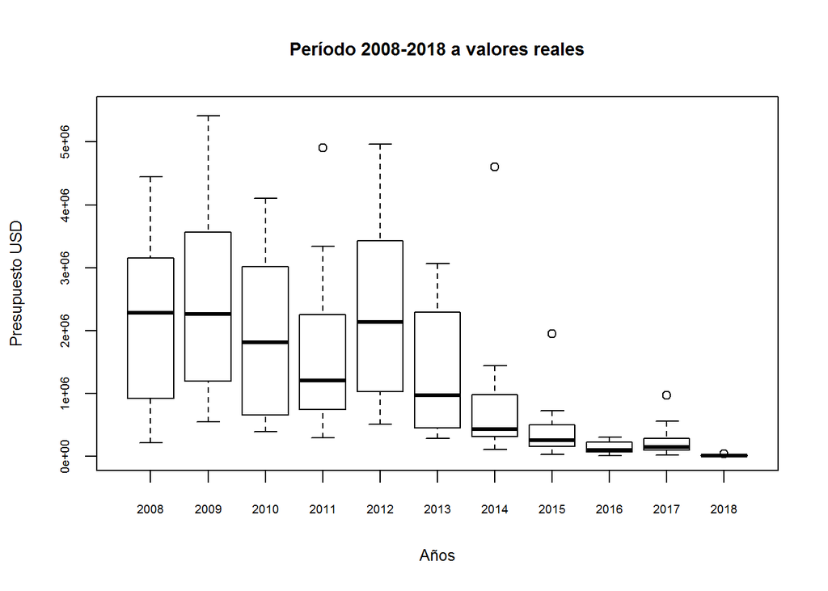

Presupuesto Cultural Estadal 2008-2018 a valores reales

```r
boxplot(reex,xlab="Años",ylab="Presupuesto USD",
main="Período 2008-2018 a valores reales",
cex.lab=0.8,cex.axis=0.6,cex.main=0.9,ylim=c(0,5500000))
```

Dada la asimetría en la distribución de los datos y la presencia de valores atípicos que afectan a la media, para comparar se elige la mediana. Se observa que la mediana se reduce aceleradamente a partir de 2013 hasta 2018. Si se comparan las medianas de cada año, tomando como base 100 al año 2008, se obtiene una representación más nítida. Para ello primero se halla la mediana de 2008 y se expresa como la base 100 y luego se divide cada valor por el valor de dicha mediana y se grafica el boxplot:

```r
m<-median(reex$`2008`,na.rm=TRUE)
m
```

```
## [1] 2284200
```

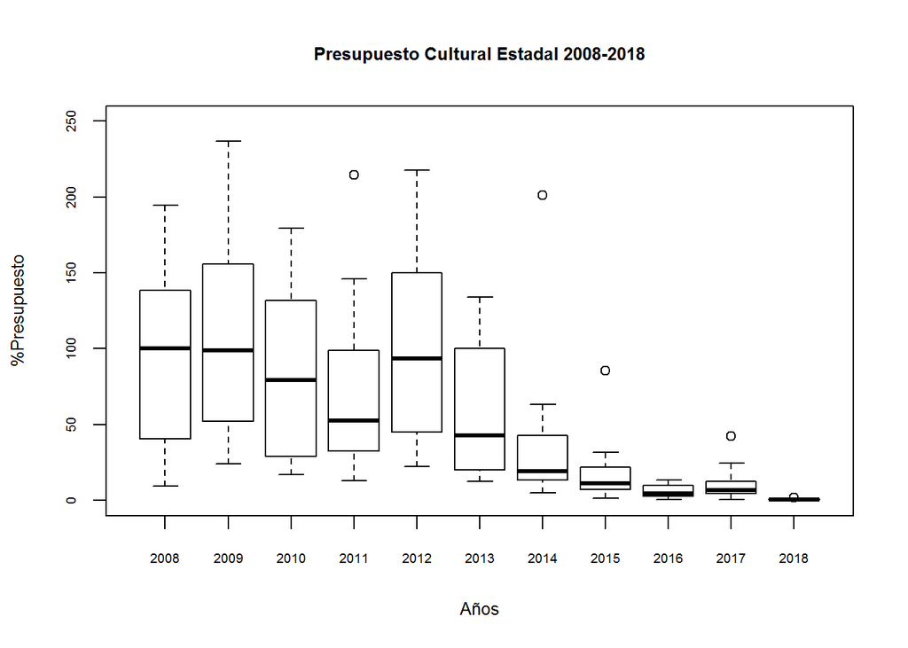

Presupuesto Cultural Estadal 2008-2018 en base a mediana de 2008

```r
reex2<-100*reex/m
boxplot(reex2,xlab="Años",
ylab="%Presupuesto",
main="Presupuesto Cultural Estadal 2008-2018",
cex.lab=0.8,cex.axis=0.6,cex.main=0.8, ylim=c(0,250))
```

Se observa una caída sostenida, y mas abrupta a partir de 2013, de una base de 100 a solo 0,5 entre 2008 y 2018 en el aporte estadal a la cultura. Una reeducción de 200 veces en el período.